# SING Aotearoa Bioinformatics Workshop 2018

Miles Benton

17 January 2018

We’re going to be exploring some of the topics that you’ve covered in genetics and epigenetics over the last couple of days. As such this workshop consists of two parts:

- **Population Genetics** - how do we explore genetic variation between populations? what does this look like?
- **Epigenetics** - can we use epigenetics in a similar way as genetic variation to distinguish cells/tissues?

## 1. Population Genetics

SNP - Single Nucleotide Polymorphisms

## Overview

The objective of this module is to give you some familiarity with the types of data and tools that are commonly used for genetic studies of population diversity.

The data we will be using are publicly available high-throughput sequencing data from the 1000 Genomes Project. The main web page for the 1000 Genomes Project is:

http://1000genomes.org

The following page provides background information about the 1000 Genomes Project (and is worth reading, particularly the information about the populations being used in the study):

http://www.1000genomes.org/about

We will be using the R and RStudio software applications to analyze the data.

R: https://cran.rstudio.com/ RStudio: https://www.rstudio.com/product/rstudio/download/

### Getting started - loading the data

The first data set we will look at contains genetic data on just a few loci (specific points in the genome) across the various populations being studied. Looking at this small data set will give you a feel for what we mean by “genotype data” for a particular locus.

Open RStudio and read in the first data set using the following command:

```r
## Read in the SNP data
snpData = read.table('data/GENE360snpData.txt',sep='\t',header=T)
```

## Looking at SNP frequencies

```r
## Make a genotype frequency table for the first SNP
table(snpData$rs3826656)
```

```
##
##   AA   AG   GG
## 1112  952  440
```

We can also calculate the proportions associated with each genotype:

```r
## Calculate proportions
prop.table(table(snpData$rs3826656))
```

```
##
##        AA        AG        GG
## 0.4440895 0.3801917 0.1757188
```

and examine differences in genotype frequencies across populations:

```r
## Create contingeny table - genotypes across populations
table(snpData$Population, snpData$rs3826656)
```

```
##
##        AA  AG  GG
##   AFR 445 199  17
##   AMR 225 109  13
##   EAS  47 224 233
##   EUR 312 161  30
##   SAS  83 259 147
```

```r
## And calculate proportions (rounded)
round(prop.table(table(snpData$Population, snpData$rs3826656),1),2)
```

```
##
##         AA   AG   GG
##   AFR 0.67 0.30 0.03
##   AMR 0.65 0.31 0.04
##   EAS 0.09 0.44 0.46
##   EUR 0.62 0.32 0.06
##   SAS 0.17 0.53 0.30
```

These results can be plotted as a bar plot:

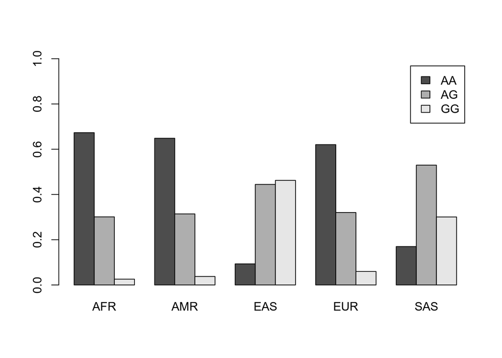

```r
snpFreqs = t(prop.table(table(snpData$Population, snpData$rs3826656), 1))
barplot(snpFreqs, beside=TRUE, legend.text=TRUE, ylim=c(0,1))
```

These analyses can be repeated for different SNPs by changing the SNP ID (e.g., rs3826656) in the above commands.

## 2. Epigenetics

```r
## Read in the methylation data for 10 different cell populations
blood_data <- read.csv('data/publicbeta_data.csv', head = T, row.names = 1, as.is = F)
```